# Risk Factor Analysis

## Outcome Variable

**Outcome Variable:** stunted

## Predictor Variables

**Intervention Variable:** earlybf

**Adjustment Set:**

- arm
- sex
- W_mage
- meducyrs
- feducyrs
- hhwealth_quart
- hfoodsec
- W_mhtcm
- W_mwtkg
- W_mbmi
- vagbrth
- W_gagebrth
- W_birthwt
- W_birthlen
- W_nrooms
- W_nchldlt5
- brthmon
- W_parity
- impfloor
- impsan
- safeh20
- delta_W_mage
- delta_meducyrs
- delta_feducyrs
- delta_hhwealth_quart
- delta_hfoodsec
- delta_W_mhtcm
- delta_W_mwtkg
- delta_W_mbmi
- delta_vagbrth
- delta_W_gagebrth
- delta_W_birthwt
- delta_W_birthlen
- delta_W_nrooms
- delta_W_nchldlt5
- delta_brthmon
- delta_W_parity
- delta_impfloor
- delta_impsan
- delta_safeh20

## Stratifying Variables

The analysis was stratified on these variable(s):

- agecat
- studyid
- country

## Data Summary

| agecat | studyid | country | earlybf | stunted | n_cell | n |
| --- | --- | --- | --- | --- | --- | --- |
| Birth | ki0047075b-MAL-ED | BANGLADESH | 1 | 0 | 126 | 230 |
| Birth | ki0047075b-MAL-ED | BANGLADESH | 1 | 1 | 21 | 230 |
| Birth | ki0047075b-MAL-ED | BANGLADESH | 0 | 0 | 60 | 230 |
| Birth | ki0047075b-MAL-ED | BANGLADESH | 0 | 1 | 23 | 230 |
| Birth | ki0047075b-MAL-ED | BRAZIL | 1 | 0 | 26 | 65 |
| Birth | ki0047075b-MAL-ED | BRAZIL | 1 | 1 | 2 | 65 |
| Birth | ki0047075b-MAL-ED | BRAZIL | 0 | 0 | 30 | 65 |
| Birth | ki0047075b-MAL-ED | BRAZIL | 0 | 1 | 7 | 65 |
| Birth | ki0047075b-MAL-ED | INDIA | 1 | 0 | 25 | 46 |
| Birth | ki0047075b-MAL-ED | INDIA | 1 | 1 | 7 | 46 |
| Birth | ki0047075b-MAL-ED | INDIA | 0 | 0 | 11 | 46 |
| Birth | ki0047075b-MAL-ED | INDIA | 0 | 1 | 3 | 46 |
| Birth | ki0047075b-MAL-ED | NEPAL | 1 | 0 | 13 | 27 |
| Birth | ki0047075b-MAL-ED | NEPAL | 1 | 1 | 1 | 27 |
| Birth | ki0047075b-MAL-ED | NEPAL | 0 | 0 | 12 | 27 |
| Birth | ki0047075b-MAL-ED | NEPAL | 0 | 1 | 1 | 27 |
| Birth | ki0047075b-MAL-ED | PERU | 1 | 0 | 158 | 233 |
| Birth | ki0047075b-MAL-ED | PERU | 1 | 1 | 17 | 233 |
| Birth | ki0047075b-MAL-ED | PERU | 0 | 0 | 49 | 233 |
| Birth | ki0047075b-MAL-ED | PERU | 0 | 1 | 9 | 233 |
| Birth | ki0047075b-MAL-ED | SOUTH AFRICA | 1 | 0 | 64 | 111 |
| Birth | ki0047075b-MAL-ED | SOUTH AFRICA | 1 | 1 | 5 | 111 |
| Birth | ki0047075b-MAL-ED | SOUTH AFRICA | 0 | 0 | 38 | 111 |
| Birth | ki0047075b-MAL-ED | SOUTH AFRICA | 0 | 1 | 4 | 111 |
| Birth | ki0047075b-MAL-ED | TANZANIA, UNITED REPUBLIC OF | 1 | 0 | 92 | 125 |
| Birth | ki0047075b-MAL-ED | TANZANIA, UNITED REPUBLIC OF | 1 | 1 | 19 | 125 |
| Birth | ki0047075b-MAL-ED | TANZANIA, UNITED REPUBLIC OF | 0 | 0 | 10 | 125 |
| Birth | ki0047075b-MAL-ED | TANZANIA, UNITED REPUBLIC OF | 0 | 1 | 4 | 125 |
| Birth | ki1000109-EE | PAKISTAN | 1 | 0 | 28 | 229 |
| Birth | ki1000109-EE | PAKISTAN | 1 | 1 | 16 | 229 |

[output cut: 134 more lines]

The following strata were considered:

- agecat: 24 months, studyid: ki0047075b-MAL-ED, country: BANGLADESH
- agecat: 24 months, studyid: ki0047075b-MAL-ED, country: BRAZIL
- agecat: 24 months, studyid: ki0047075b-MAL-ED, country: INDIA
- agecat: 24 months, studyid: ki0047075b-MAL-ED, country: NEPAL
- agecat: 24 months, studyid: ki0047075b-MAL-ED, country: PERU
- agecat: 24 months, studyid: ki0047075b-MAL-ED, country: SOUTH AFRICA
- agecat: 24 months, studyid: ki0047075b-MAL-ED, country: TANZANIA, UNITED REPUBLIC OF
- agecat: 24 months, studyid: ki1000109-EE, country: PAKISTAN
- agecat: 24 months, studyid: ki1017093c-NIH-Crypto, country: BANGLADESH
- agecat: 24 months, studyid: ki1113344-GMS-Nepal, country: NEPAL
- agecat: 24 months, studyid: ki1126311-ZVITAMBO, country: ZIMBABWE
- agecat: 24 months, studyid: kiGH5241-JiVitA-3, country: BANGLADESH
- agecat: 24 months, studyid: kiGH5241-JiVitA-4, country: BANGLADESH
- agecat: 6 months, studyid: ki0047075b-MAL-ED, country: BANGLADESH
- agecat: 6 months, studyid: ki0047075b-MAL-ED, country: BRAZIL
- agecat: 6 months, studyid: ki0047075b-MAL-ED, country: INDIA
- agecat: 6 months, studyid: ki0047075b-MAL-ED, country: NEPAL
- agecat: 6 months, studyid: ki0047075b-MAL-ED, country: PERU
- agecat: 6 months, studyid: ki0047075b-MAL-ED, country: SOUTH AFRICA
- agecat: 6 months, studyid: ki0047075b-MAL-ED, country: TANZANIA, UNITED REPUBLIC OF
- agecat: 6 months, studyid: ki1000109-EE, country: PAKISTAN
- agecat: 6 months, studyid: ki1000304b-SAS-CompFeed, country: INDIA
- agecat: 6 months, studyid: ki1017093c-NIH-Crypto, country: BANGLADESH
- agecat: 6 months, studyid: ki1113344-GMS-Nepal, country: NEPAL
- agecat: 6 months, studyid: ki1126311-ZVITAMBO, country: ZIMBABWE
- agecat: 6 months, studyid: kiGH5241-JiVitA-3, country: BANGLADESH
- agecat: 6 months, studyid: kiGH5241-JiVitA-4, country: BANGLADESH
- agecat: Birth, studyid: ki0047075b-MAL-ED, country: BANGLADESH
- agecat: Birth, studyid: ki0047075b-MAL-ED, country: BRAZIL
- agecat: Birth, studyid: ki0047075b-MAL-ED, country: INDIA
- agecat: Birth, studyid: ki0047075b-MAL-ED, country: NEPAL
- agecat: Birth, studyid: ki0047075b-MAL-ED, country: PERU
- agecat: Birth, studyid: ki0047075b-MAL-ED, country: SOUTH AFRICA
- agecat: Birth, studyid: ki0047075b-MAL-ED, country: TANZANIA, UNITED REPUBLIC OF
- agecat: Birth, studyid: ki1000109-EE, country: PAKISTAN
- agecat: Birth, studyid: ki1000304b-SAS-CompFeed, country: INDIA
- agecat: Birth, studyid: ki1017093c-NIH-Crypto, country: BANGLADESH
- agecat: Birth, studyid: ki1113344-GMS-Nepal, country: NEPAL
- agecat: Birth, studyid: ki1126311-ZVITAMBO, country: ZIMBABWE
- agecat: Birth, studyid: kiGH5241-JiVitA-3, country: BANGLADESH
- agecat: Birth, studyid: kiGH5241-JiVitA-4, country: BANGLADESH

### Dropped Strata

Some strata were dropped due to rare outcomes:

- agecat: Birth, studyid: ki0047075b-MAL-ED, country: BRAZIL
- agecat: Birth, studyid: ki0047075b-MAL-ED, country: INDIA
- agecat: Birth, studyid: ki0047075b-MAL-ED, country: NEPAL
- agecat: Birth, studyid: ki0047075b-MAL-ED, country: SOUTH AFRICA
- agecat: Birth, studyid: ki0047075b-MAL-ED, country: TANZANIA, UNITED REPUBLIC OF
- agecat: 6 months, studyid: ki0047075b-MAL-ED, country: BRAZIL
- agecat: 6 months, studyid: ki0047075b-MAL-ED, country: NEPAL
- agecat: 24 months, studyid: ki0047075b-MAL-ED, country: BRAZIL
- agecat: 24 months, studyid: kiGH5241-JiVitA-3, country: BANGLADESH

## Methods Detail

We’re interested in the causal parameters $E[Y_a]$ for all values of $a \in \mathcal{A}$. These parameters represent the mean outcome if, possibly contrary to fact, we intervened to set all units to have $A=a$. Under the randomization and positivity assumptions, these are identified by the statistical parameters $\psi_a=E_W[E_{Y|A,W}(Y|A=a,W)]$. In addition, we’re interested in the mean of $Y$, $E[Y]$ under no intervention (the observed mean). We will estimate these parameters by using SuperLearner to fit the relevant likelihood factors – $E_{Y|A,W}(Y|A=a,W)$ and $p(A=a|W)$, and then updating our likelihood fit using a joint TMLE.

For unadjusted analyses ($W=\{\}$), initial likelihoods were estimated using Lrnr_glm to estimate the simple $E(Y|A)$ and Lrnr_mean to estimate $p(A)$. For adjusted analyses, a small library containing Lrnr_glmnet, Lrnr_xgboost, and Lrnr_mean was used.

Having estimated these parameters, we will then use the delta method to estimate relative risks and attributable risks relative to a prespecified baseline level of $A$.

# Results Detail

## Results Plots

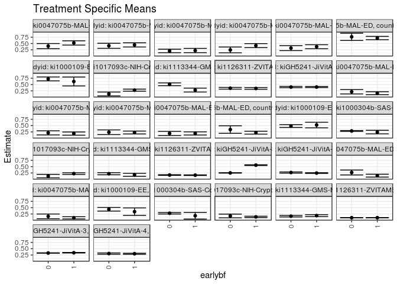

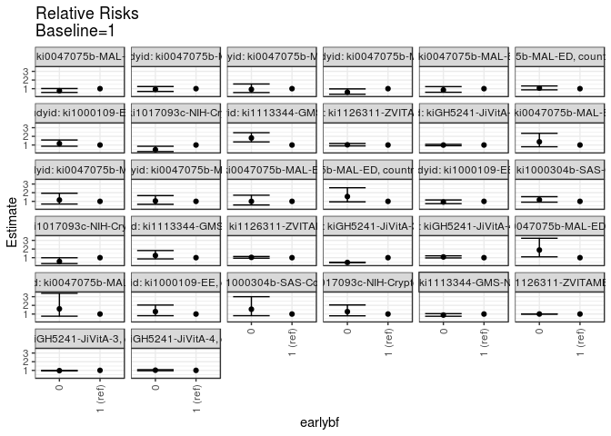

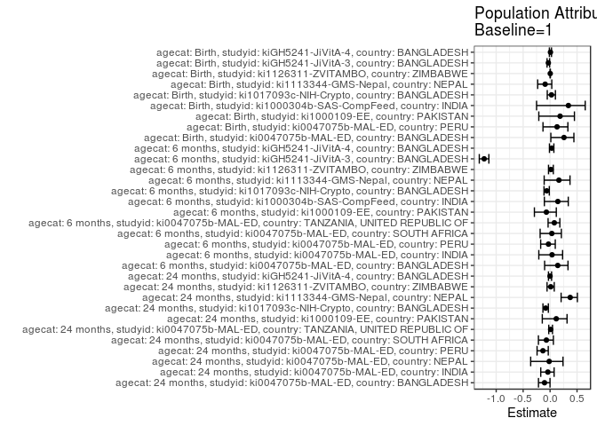

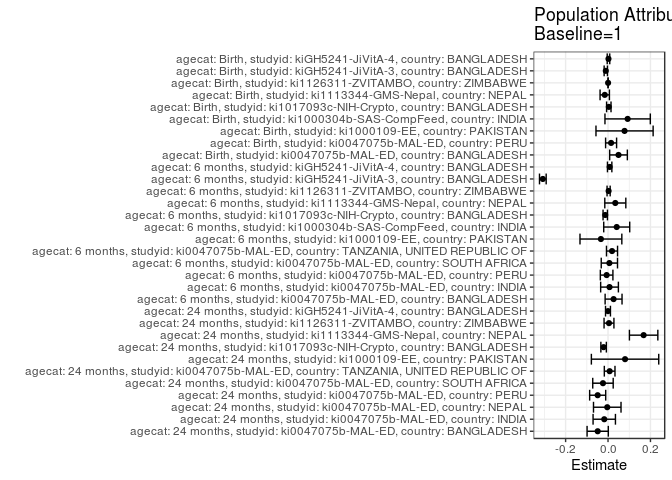

## Results Table

### Parameter: TSM

| agecat | studyid | country | intervention_level | baseline_level | estimate | ci_lower | ci_upper |
| --- | --- | --- | --- | --- | --- | --- | --- |
| Birth | ki0047075b-MAL-ED | BANGLADESH | 1 | NA | 0.1418947 | 0.0849482 | 0.1988412 |
| Birth | ki0047075b-MAL-ED | BANGLADESH | 0 | NA | 0.2676135 | 0.1708269 | 0.3644001 |
| Birth | ki0047075b-MAL-ED | PERU | 1 | NA | 0.0971429 | 0.0531707 | 0.1411150 |
| Birth | ki0047075b-MAL-ED | PERU | 0 | NA | 0.1551724 | 0.0617912 | 0.2485536 |
| Birth | ki1000109-EE | PAKISTAN | 1 | NA | 0.3413354 | 0.1935518 | 0.4891190 |
| Birth | ki1000109-EE | PAKISTAN | 0 | NA | 0.4375886 | 0.3654605 | 0.5097166 |
| Birth | ki1000304b-SAS-CompFeed | INDIA | 1 | NA | 0.1793114 | 0.0480923 | 0.3105306 |
| Birth | ki1000304b-SAS-CompFeed | INDIA | 0 | NA | 0.2789015 | 0.2498198 | 0.3079832 |
| Birth | ki1017093c-NIH-Crypto | BANGLADESH | 1 | NA | 0.1343515 | 0.1078106 | 0.1608924 |
| Birth | ki1017093c-NIH-Crypto | BANGLADESH | 0 | NA | 0.1713338 | 0.0975074 | 0.2451601 |
| Birth | ki1113344-GMS-Nepal | NEPAL | 1 | NA | 0.1847995 | 0.1475367 | 0.2220624 |
| Birth | ki1113344-GMS-Nepal | NEPAL | 0 | NA | 0.1626133 | 0.1326122 | 0.1926144 |
| Birth | ki1126311-ZVITAMBO | ZIMBABWE | 1 | NA | 0.1024849 | 0.0971364 | 0.1078333 |
| Birth | ki1126311-ZVITAMBO | ZIMBABWE | 0 | NA | 0.1028550 | 0.0974894 | 0.1082206 |
| Birth | kiGH5241-JiVitA-3 | BANGLADESH | 1 | NA | 0.3396270 | 0.3289739 | 0.3502801 |
| Birth | kiGH5241-JiVitA-3 | BANGLADESH | 0 | NA | 0.3289679 | 0.3215915 | 0.3363443 |
| Birth | kiGH5241-JiVitA-4 | BANGLADESH | 1 | NA | 0.3014801 | 0.2813622 | 0.3215981 |
| Birth | kiGH5241-JiVitA-4 | BANGLADESH | 0 | NA | 0.3073867 | 0.2825594 | 0.3322140 |
| 6 months | ki0047075b-MAL-ED | BANGLADESH | 1 | NA | 0.1572036 | 0.0992023 | 0.2152049 |
| 6 months | ki0047075b-MAL-ED | BANGLADESH | 0 | NA | 0.2150373 | 0.1284184 | 0.3016562 |
| 6 months | ki0047075b-MAL-ED | INDIA | 1 | NA | 0.1836572 | 0.1203850 | 0.2469295 |
| 6 months | ki0047075b-MAL-ED | INDIA | 0 | NA | 0.2123181 | 0.1301930 | 0.2944433 |
| 6 months | ki0047075b-MAL-ED | PERU | 1 | NA | 0.2264134 | 0.1688778 | 0.2839491 |
| 6 months | ki0047075b-MAL-ED | PERU | 0 | NA | 0.2368931 | 0.1446081 | 0.3291782 |
| 6 months | ki0047075b-MAL-ED | SOUTH AFRICA | 1 | NA | 0.1896663 | 0.1276007 | 0.2517318 |
| 6 months | ki0047075b-MAL-ED | SOUTH AFRICA | 0 | NA | 0.1890189 | 0.1071415 | 0.2708962 |
| 6 months | ki0047075b-MAL-ED | TANZANIA, UNITED REPUBLIC OF | 1 | NA | 0.2200760 | 0.1631436 | 0.2770084 |
| 6 months | ki0047075b-MAL-ED | TANZANIA, UNITED REPUBLIC OF | 0 | NA | 0.3427369 | 0.1935991 | 0.4918747 |
| 6 months | ki1000109-EE | PAKISTAN | 1 | NA | 0.5225254 | 0.4117903 | 0.6332606 |
| 6 months | ki1000109-EE | PAKISTAN | 0 | NA | 0.4814090 | 0.4249653 | 0.5378527 |
| 6 months | ki1000304b-SAS-CompFeed | INDIA | 1 | NA | 0.2434917 | 0.1728276 | 0.3141558 |
| 6 months | ki1000304b-SAS-CompFeed | INDIA | 0 | NA | 0.2873470 | 0.2702123 | 0.3044817 |
| 6 months | ki1017093c-NIH-Crypto | BANGLADESH | 1 | NA | 0.2228836 | 0.1900976 | 0.2556696 |
| 6 months | ki1017093c-NIH-Crypto | BANGLADESH | 0 | NA | 0.1258953 | 0.0576153 | 0.1941754 |
| 6 months | ki1113344-GMS-Nepal | NEPAL | 1 | NA | 0.1751128 | 0.1162422 | 0.2339833 |
| 6 months | ki1113344-GMS-Nepal | NEPAL | 0 | NA | 0.2192186 | 0.1771863 | 0.2612509 |
| 6 months | ki1126311-ZVITAMBO | ZIMBABWE | 1 | NA | 0.1614713 | 0.1505688 | 0.1723738 |
| 6 months | ki1126311-ZVITAMBO | ZIMBABWE | 0 | NA | 0.1672352 | 0.1553422 | 0.1791281 |
| 6 months | kiGH5241-JiVitA-3 | BANGLADESH | 1 | NA | 0.5587501 | 0.5450391 | 0.5724612 |
| 6 months | kiGH5241-JiVitA-3 | BANGLADESH | 0 | NA | 0.2507332 | 0.2424133 | 0.2590530 |
| 6 months | kiGH5241-JiVitA-4 | BANGLADESH | 1 | NA | 0.2450822 | 0.2279411 | 0.2622233 |
| 6 months | kiGH5241-JiVitA-4 | BANGLADESH | 0 | NA | 0.2667202 | 0.2428042 | 0.2906362 |
| 24 months | ki0047075b-MAL-ED | BANGLADESH | 1 | NA | 0.5227022 | 0.4389117 | 0.6064928 |
| 24 months | ki0047075b-MAL-ED | BANGLADESH | 0 | NA | 0.3967349 | 0.2940046 | 0.4994651 |
| 24 months | ki0047075b-MAL-ED | INDIA | 1 | NA | 0.4451095 | 0.3619545 | 0.5282646 |
| 24 months | ki0047075b-MAL-ED | INDIA | 0 | NA | 0.4099542 | 0.3102902 | 0.5096182 |
| 24 months | ki0047075b-MAL-ED | NEPAL | 1 | NA | 0.2229434 | 0.1372207 | 0.3086660 |
| 24 months | ki0047075b-MAL-ED | NEPAL | 0 | NA | 0.2052678 | 0.1354603 | 0.2750754 |
| 24 months | ki0047075b-MAL-ED | PERU | 1 | NA | 0.4170104 | 0.3375486 | 0.4964721 |
| 24 months | ki0047075b-MAL-ED | PERU | 0 | NA | 0.2462840 | 0.1311959 | 0.3613721 |
| 24 months | ki0047075b-MAL-ED | SOUTH AFRICA | 1 | NA | 0.3728046 | 0.2935126 | 0.4520966 |
| 24 months | ki0047075b-MAL-ED | SOUTH AFRICA | 0 | NA | 0.3171954 | 0.2197023 | 0.4146884 |
| 24 months | ki0047075b-MAL-ED | TANZANIA, UNITED REPUBLIC OF | 1 | NA | 0.7166667 | 0.6506830 | 0.7826503 |
| 24 months | ki0047075b-MAL-ED | TANZANIA, UNITED REPUBLIC OF | 0 | NA | 0.7647059 | 0.6217907 | 0.9076211 |
| 24 months | ki1000109-EE | PAKISTAN | 1 | NA | 0.6209818 | 0.4446662 | 0.7972974 |
| 24 months | ki1000109-EE | PAKISTAN | 0 | NA | 0.7231662 | 0.6466784 | 0.7996541 |
| 24 months | ki1017093c-NIH-Crypto | BANGLADESH | 1 | NA | 0.2776524 | 0.2359085 | 0.3193963 |
| 24 months | ki1017093c-NIH-Crypto | BANGLADESH | 0 | NA | 0.1267606 | 0.0492965 | 0.2042247 |
| 24 months | ki1113344-GMS-Nepal | NEPAL | 1 | NA | 0.2816435 | 0.2049584 | 0.3583286 |
| 24 months | ki1113344-GMS-Nepal | NEPAL | 0 | NA | 0.5102322 | 0.4551926 | 0.5652719 |
| 24 months | ki1126311-ZVITAMBO | ZIMBABWE | 1 | NA | 0.3454219 | 0.3114058 | 0.3794380 |
| 24 months | ki1126311-ZVITAMBO | ZIMBABWE | 0 | NA | 0.3539152 | 0.3190898 | 0.3887406 |
| 24 months | kiGH5241-JiVitA-4 | BANGLADESH | 1 | NA | 0.4011072 | 0.3801530 | 0.4220615 |
| 24 months | kiGH5241-JiVitA-4 | BANGLADESH | 0 | NA | 0.3995732 | 0.3730238 | 0.4261227 |

### Parameter: E(Y)

| agecat | studyid | country | intervention_level | baseline_level | estimate | ci_lower | ci_upper |
| --- | --- | --- | --- | --- | --- | --- | --- |
| Birth | ki0047075b-MAL-ED | BANGLADESH | NA | NA | 0.1913043 | 0.1403613 | 0.2422474 |
| Birth | ki0047075b-MAL-ED | PERU | NA | NA | 0.1115880 | 0.0710726 | 0.1521034 |
| Birth | ki1000109-EE | PAKISTAN | NA | NA | 0.4192140 | 0.3551658 | 0.4832621 |
| Birth | ki1000304b-SAS-CompFeed | INDIA | NA | NA | 0.2717481 | 0.2380003 | 0.3054960 |
| Birth | ki1017093c-NIH-Crypto | BANGLADESH | NA | NA | 0.1379781 | 0.1129774 | 0.1629789 |
| Birth | ki1113344-GMS-Nepal | NEPAL | NA | NA | 0.1693038 | 0.1400429 | 0.1985647 |
| Birth | ki1126311-ZVITAMBO | ZIMBABWE | NA | NA | 0.1028007 | 0.0974452 | 0.1081563 |
| Birth | kiGH5241-JiVitA-3 | BANGLADESH | NA | NA | 0.3290568 | 0.3216837 | 0.3364298 |
| Birth | kiGH5241-JiVitA-4 | BANGLADESH | NA | NA | 0.3035778 | 0.2836422 | 0.3235133 |
| 6 months | ki0047075b-MAL-ED | BANGLADESH | NA | NA | 0.1833333 | 0.1342773 | 0.2323893 |
| 6 months | ki0047075b-MAL-ED | INDIA | NA | NA | 0.1906780 | 0.1404524 | 0.2409036 |
| 6 months | ki0047075b-MAL-ED | PERU | NA | NA | 0.2197802 | 0.1705687 | 0.2689917 |
| 6 months | ki0047075b-MAL-ED | SOUTH AFRICA | NA | NA | 0.1960000 | 0.1466935 | 0.2453065 |
| 6 months | ki0047075b-MAL-ED | TANZANIA, UNITED REPUBLIC OF | NA | NA | 0.2388664 | 0.1855834 | 0.2921494 |
| 6 months | ki1000109-EE | PAKISTAN | NA | NA | 0.4889503 | 0.4373849 | 0.5405157 |
| 6 months | ki1000304b-SAS-CompFeed | INDIA | NA | NA | 0.2844311 | 0.2666491 | 0.3022132 |
| 6 months | ki1017093c-NIH-Crypto | BANGLADESH | NA | NA | 0.2097902 | 0.1799252 | 0.2396552 |
| 6 months | ki1113344-GMS-Nepal | NEPAL | NA | NA | 0.2093933 | 0.1740812 | 0.2447055 |
| 6 months | ki1126311-ZVITAMBO | ZIMBABWE | NA | NA | 0.1641985 | 0.1559224 | 0.1724746 |
| 6 months | kiGH5241-JiVitA-3 | BANGLADESH | NA | NA | 0.2513830 | 0.2432594 | 0.2595066 |
| 6 months | kiGH5241-JiVitA-4 | BANGLADESH | NA | NA | 0.2527427 | 0.2386864 | 0.2667990 |
| 24 months | ki0047075b-MAL-ED | BANGLADESH | NA | NA | 0.4739336 | 0.4064004 | 0.5414669 |
| 24 months | ki0047075b-MAL-ED | INDIA | NA | NA | 0.4273128 | 0.3628178 | 0.4918077 |
| 24 months | ki0047075b-MAL-ED | NEPAL | NA | NA | 0.2192982 | 0.1654718 | 0.2731246 |
| 24 months | ki0047075b-MAL-ED | PERU | NA | NA | 0.3681592 | 0.3013164 | 0.4350020 |
| 24 months | ki0047075b-MAL-ED | SOUTH AFRICA | NA | NA | 0.3489362 | 0.2878666 | 0.4100058 |
| 24 months | ki0047075b-MAL-ED | TANZANIA, UNITED REPUBLIC OF | NA | NA | 0.7242991 | 0.6642873 | 0.7843108 |
| 24 months | ki1000109-EE | PAKISTAN | NA | NA | 0.7012195 | 0.6309515 | 0.7714875 |
| 24 months | ki1017093c-NIH-Crypto | BANGLADESH | NA | NA | 0.2568093 | 0.2190047 | 0.2946140 |
| 24 months | ki1113344-GMS-Nepal | NEPAL | NA | NA | 0.4494382 | 0.4031687 | 0.4957077 |
| 24 months | ki1126311-ZVITAMBO | ZIMBABWE | NA | NA | 0.3499289 | 0.3249898 | 0.3748679 |
| 24 months | kiGH5241-JiVitA-4 | BANGLADESH | NA | NA | 0.4008838 | 0.3839145 | 0.4178532 |

### Parameter: RR

| agecat | studyid | country | intervention_level | baseline_level | estimate | ci_lower | ci_upper |
| --- | --- | --- | --- | --- | --- | --- | --- |
| Birth | ki0047075b-MAL-ED | BANGLADESH | 1 | 1 | 1.0000000 | 1.0000000 | 1.0000000 |
| Birth | ki0047075b-MAL-ED | BANGLADESH | 0 | 1 | 1.8860008 | 1.0973577 | 3.2414217 |
| Birth | ki0047075b-MAL-ED | PERU | 1 | 1 | 1.0000000 | 1.0000000 | 1.0000000 |
| Birth | ki0047075b-MAL-ED | PERU | 0 | 1 | 1.5973630 | 0.7522615 | 3.3918640 |
| Birth | ki1000109-EE | PAKISTAN | 1 | 1 | 1.0000000 | 1.0000000 | 1.0000000 |
| Birth | ki1000109-EE | PAKISTAN | 0 | 1 | 1.2819901 | 0.8069521 | 2.0366742 |
| Birth | ki1000304b-SAS-CompFeed | INDIA | 1 | 1 | 1.0000000 | 1.0000000 | 1.0000000 |
| Birth | ki1000304b-SAS-CompFeed | INDIA | 0 | 1 | 1.5554028 | 0.8060709 | 3.0013214 |
| Birth | ki1017093c-NIH-Crypto | BANGLADESH | 1 | 1 | 1.0000000 | 1.0000000 | 1.0000000 |
| Birth | ki1017093c-NIH-Crypto | BANGLADESH | 0 | 1 | 1.2752650 | 0.7940735 | 2.0480483 |
| Birth | ki1113344-GMS-Nepal | NEPAL | 1 | 1 | 1.0000000 | 1.0000000 | 1.0000000 |
| Birth | ki1113344-GMS-Nepal | NEPAL | 0 | 1 | 0.8799443 | 0.7417170 | 1.0439318 |
| Birth | ki1126311-ZVITAMBO | ZIMBABWE | 1 | 1 | 1.0000000 | 1.0000000 | 1.0000000 |
| Birth | ki1126311-ZVITAMBO | ZIMBABWE | 0 | 1 | 1.0036112 | 0.9982220 | 1.0090295 |
| Birth | kiGH5241-JiVitA-3 | BANGLADESH | 1 | 1 | 1.0000000 | 1.0000000 | 1.0000000 |
| Birth | kiGH5241-JiVitA-3 | BANGLADESH | 0 | 1 | 0.9686151 | 0.9461019 | 0.9916641 |
| Birth | kiGH5241-JiVitA-4 | BANGLADESH | 1 | 1 | 1.0000000 | 1.0000000 | 1.0000000 |
| Birth | kiGH5241-JiVitA-4 | BANGLADESH | 0 | 1 | 1.0195919 | 0.9594706 | 1.0834804 |
| 6 months | ki0047075b-MAL-ED | BANGLADESH | 1 | 1 | 1.0000000 | 1.0000000 | 1.0000000 |
| 6 months | ki0047075b-MAL-ED | BANGLADESH | 0 | 1 | 1.3678907 | 0.7965426 | 2.3490581 |
| 6 months | ki0047075b-MAL-ED | INDIA | 1 | 1 | 1.0000000 | 1.0000000 | 1.0000000 |
| 6 months | ki0047075b-MAL-ED | INDIA | 0 | 1 | 1.1560564 | 0.6897394 | 1.9376396 |
| 6 months | ki0047075b-MAL-ED | PERU | 1 | 1 | 1.0000000 | 1.0000000 | 1.0000000 |
| 6 months | ki0047075b-MAL-ED | PERU | 0 | 1 | 1.0462857 | 0.6573725 | 1.6652869 |
| 6 months | ki0047075b-MAL-ED | SOUTH AFRICA | 1 | 1 | 1.0000000 | 1.0000000 | 1.0000000 |
| 6 months | ki0047075b-MAL-ED | SOUTH AFRICA | 0 | 1 | 0.9965867 | 0.5808073 | 1.7100076 |
| 6 months | ki0047075b-MAL-ED | TANZANIA, UNITED REPUBLIC OF | 1 | 1 | 1.0000000 | 1.0000000 | 1.0000000 |
| 6 months | ki0047075b-MAL-ED | TANZANIA, UNITED REPUBLIC OF | 0 | 1 | 1.5573572 | 0.9439680 | 2.5693258 |
| 6 months | ki1000109-EE | PAKISTAN | 1 | 1 | 1.0000000 | 1.0000000 | 1.0000000 |
| 6 months | ki1000109-EE | PAKISTAN | 0 | 1 | 0.9213122 | 0.7304518 | 1.1620426 |
| 6 months | ki1000304b-SAS-CompFeed | INDIA | 1 | 1 | 1.0000000 | 1.0000000 | 1.0000000 |
| 6 months | ki1000304b-SAS-CompFeed | INDIA | 0 | 1 | 1.1801101 | 0.9044645 | 1.5397617 |
| 6 months | ki1017093c-NIH-Crypto | BANGLADESH | 1 | 1 | 1.0000000 | 1.0000000 | 1.0000000 |
| 6 months | ki1017093c-NIH-Crypto | BANGLADESH | 0 | 1 | 0.5648480 | 0.3219767 | 0.9909203 |
| 6 months | ki1113344-GMS-Nepal | NEPAL | 1 | 1 | 1.0000000 | 1.0000000 | 1.0000000 |
| 6 months | ki1113344-GMS-Nepal | NEPAL | 0 | 1 | 1.2518709 | 0.8599444 | 1.8224209 |
| 6 months | ki1126311-ZVITAMBO | ZIMBABWE | 1 | 1 | 1.0000000 | 1.0000000 | 1.0000000 |
| 6 months | ki1126311-ZVITAMBO | ZIMBABWE | 0 | 1 | 1.0356959 | 0.9425004 | 1.1381067 |
| 6 months | kiGH5241-JiVitA-3 | BANGLADESH | 1 | 1 | 1.0000000 | 1.0000000 | 1.0000000 |
| 6 months | kiGH5241-JiVitA-3 | BANGLADESH | 0 | 1 | 0.4487394 | 0.4304845 | 0.4677683 |
| 6 months | kiGH5241-JiVitA-4 | BANGLADESH | 1 | 1 | 1.0000000 | 1.0000000 | 1.0000000 |
| 6 months | kiGH5241-JiVitA-4 | BANGLADESH | 0 | 1 | 1.0882885 | 0.9728330 | 1.2174462 |
| 24 months | ki0047075b-MAL-ED | BANGLADESH | 1 | 1 | 1.0000000 | 1.0000000 | 1.0000000 |
| 24 months | ki0047075b-MAL-ED | BANGLADESH | 0 | 1 | 0.7590074 | 0.5674856 | 1.0151663 |
| 24 months | ki0047075b-MAL-ED | INDIA | 1 | 1 | 1.0000000 | 1.0000000 | 1.0000000 |
| 24 months | ki0047075b-MAL-ED | INDIA | 0 | 1 | 0.9210188 | 0.6804644 | 1.2466128 |
| 24 months | ki0047075b-MAL-ED | NEPAL | 1 | 1 | 1.0000000 | 1.0000000 | 1.0000000 |
| 24 months | ki0047075b-MAL-ED | NEPAL | 0 | 1 | 0.9207175 | 0.5501772 | 1.5408140 |
| 24 months | ki0047075b-MAL-ED | PERU | 1 | 1 | 1.0000000 | 1.0000000 | 1.0000000 |
| 24 months | ki0047075b-MAL-ED | PERU | 0 | 1 | 0.5905944 | 0.3577871 | 0.9748864 |
| 24 months | ki0047075b-MAL-ED | SOUTH AFRICA | 1 | 1 | 1.0000000 | 1.0000000 | 1.0000000 |
| 24 months | ki0047075b-MAL-ED | SOUTH AFRICA | 0 | 1 | 0.8508354 | 0.5847982 | 1.2378986 |
| 24 months | ki0047075b-MAL-ED | TANZANIA, UNITED REPUBLIC OF | 1 | 1 | 1.0000000 | 1.0000000 | 1.0000000 |
| 24 months | ki0047075b-MAL-ED | TANZANIA, UNITED REPUBLIC OF | 0 | 1 | 1.0670315 | 0.8663581 | 1.3141865 |
| 24 months | ki1000109-EE | PAKISTAN | 1 | 1 | 1.0000000 | 1.0000000 | 1.0000000 |
| 24 months | ki1000109-EE | PAKISTAN | 0 | 1 | 1.1645530 | 0.8592036 | 1.5784194 |
| 24 months | ki1017093c-NIH-Crypto | BANGLADESH | 1 | 1 | 1.0000000 | 1.0000000 | 1.0000000 |
| 24 months | ki1017093c-NIH-Crypto | BANGLADESH | 0 | 1 | 0.4565441 | 0.2433150 | 0.8566365 |
| 24 months | ki1113344-GMS-Nepal | NEPAL | 1 | 1 | 1.0000000 | 1.0000000 | 1.0000000 |
| 24 months | ki1113344-GMS-Nepal | NEPAL | 0 | 1 | 1.8116243 | 1.3557975 | 2.4207025 |
| 24 months | ki1126311-ZVITAMBO | ZIMBABWE | 1 | 1 | 1.0000000 | 1.0000000 | 1.0000000 |
| 24 months | ki1126311-ZVITAMBO | ZIMBABWE | 0 | 1 | 1.0245881 | 0.8954452 | 1.1723562 |
| 24 months | kiGH5241-JiVitA-4 | BANGLADESH | 1 | 1 | 1.0000000 | 1.0000000 | 1.0000000 |
| 24 months | kiGH5241-JiVitA-4 | BANGLADESH | 0 | 1 | 0.9961756 | 0.9188148 | 1.0800499 |

### Parameter: PAR

| agecat | studyid | country | intervention_level | baseline_level | estimate | ci_lower | ci_upper |
| --- | --- | --- | --- | --- | --- | --- | --- |
| Birth | ki0047075b-MAL-ED | BANGLADESH | 1 | NA | 0.0494096 | 0.0077220 | 0.0910973 |
| Birth | ki0047075b-MAL-ED | PERU | 1 | NA | 0.0144451 | -0.0114503 | 0.0403405 |
| Birth | ki1000109-EE | PAKISTAN | 1 | NA | 0.0778786 | -0.0568243 | 0.2125815 |
| Birth | ki1000304b-SAS-CompFeed | INDIA | 1 | NA | 0.0924367 | -0.0144782 | 0.1993516 |
| Birth | ki1017093c-NIH-Crypto | BANGLADESH | 1 | NA | 0.0036266 | -0.0068091 | 0.0140623 |
| Birth | ki1113344-GMS-Nepal | NEPAL | 1 | NA | -0.0154957 | -0.0375316 | 0.0065401 |
| Birth | ki1126311-ZVITAMBO | ZIMBABWE | 1 | NA | 0.0003158 | 0.0000239 | 0.0006078 |
| Birth | kiGH5241-JiVitA-3 | BANGLADESH | 1 | NA | -0.0105702 | -0.0183441 | -0.0027963 |
| Birth | kiGH5241-JiVitA-4 | BANGLADESH | 1 | NA | 0.0020976 | -0.0039117 | 0.0081069 |
| 6 months | ki0047075b-MAL-ED | BANGLADESH | 1 | NA | 0.0261298 | -0.0137234 | 0.0659829 |
| 6 months | ki0047075b-MAL-ED | INDIA | 1 | NA | 0.0070207 | -0.0347727 | 0.0488141 |
| 6 months | ki0047075b-MAL-ED | PERU | 1 | NA | -0.0066332 | -0.0362602 | 0.0229938 |
| 6 months | ki0047075b-MAL-ED | SOUTH AFRICA | 1 | NA | 0.0063337 | -0.0320032 | 0.0446707 |
| 6 months | ki0047075b-MAL-ED | TANZANIA, UNITED REPUBLIC OF | 1 | NA | 0.0187904 | -0.0072943 | 0.0448752 |
| 6 months | ki1000109-EE | PAKISTAN | 1 | NA | -0.0335751 | -0.1322129 | 0.0650627 |
| 6 months | ki1000304b-SAS-CompFeed | INDIA | 1 | NA | 0.0409394 | -0.0203150 | 0.1021939 |
| 6 months | ki1017093c-NIH-Crypto | BANGLADESH | 1 | NA | -0.0130934 | -0.0234860 | -0.0027007 |
| 6 months | ki1113344-GMS-Nepal | NEPAL | 1 | NA | 0.0342806 | -0.0152905 | 0.0838516 |
| 6 months | ki1126311-ZVITAMBO | ZIMBABWE | 1 | NA | 0.0027272 | -0.0045878 | 0.0100422 |
| 6 months | kiGH5241-JiVitA-3 | BANGLADESH | 1 | NA | -0.3073671 | -0.3230989 | -0.2916354 |
| 6 months | kiGH5241-JiVitA-4 | BANGLADESH | 1 | NA | 0.0076605 | -0.0026962 | 0.0180172 |
| 24 months | ki0047075b-MAL-ED | BANGLADESH | 1 | NA | -0.0487686 | -0.0988008 | 0.0012636 |
| 24 months | ki0047075b-MAL-ED | INDIA | 1 | NA | -0.0177967 | -0.0705265 | 0.0349330 |
| 24 months | ki0047075b-MAL-ED | NEPAL | 1 | NA | -0.0036451 | -0.0685033 | 0.0612131 |
| 24 months | ki0047075b-MAL-ED | PERU | 1 | NA | -0.0488512 | -0.0866869 | -0.0110154 |
| 24 months | ki0047075b-MAL-ED | SOUTH AFRICA | 1 | NA | -0.0238684 | -0.0720970 | 0.0243601 |
| 24 months | ki0047075b-MAL-ED | TANZANIA, UNITED REPUBLIC OF | 1 | NA | 0.0076324 | -0.0174880 | 0.0327528 |
| 24 months | ki1000109-EE | PAKISTAN | 1 | NA | 0.0802377 | -0.0785434 | 0.2390188 |
| 24 months | ki1017093c-NIH-Crypto | BANGLADESH | 1 | NA | -0.0208430 | -0.0338062 | -0.0078799 |
| 24 months | ki1113344-GMS-Nepal | NEPAL | 1 | NA | 0.1677947 | 0.1008186 | 0.2347708 |
| 24 months | ki1126311-ZVITAMBO | ZIMBABWE | 1 | NA | 0.0045070 | -0.0187745 | 0.0277884 |
| 24 months | kiGH5241-JiVitA-4 | BANGLADESH | 1 | NA | -0.0002234 | -0.0117957 | 0.0113489 |

### Parameter: PAF

| agecat | studyid | country | intervention_level | baseline_level | estimate | ci_lower | ci_upper |
| --- | --- | --- | --- | --- | --- | --- | --- |
| Birth | ki0047075b-MAL-ED | BANGLADESH | 1 | NA | 0.2582777 | 0.0141996 | 0.4419236 |
| Birth | ki0047075b-MAL-ED | PERU | 1 | NA | 0.1294505 | -0.1316004 | 0.3302792 |
| Birth | ki1000109-EE | PAKISTAN | 1 | NA | 0.1857729 | -0.2090509 | 0.4516643 |
| Birth | ki1000304b-SAS-CompFeed | INDIA | 1 | NA | 0.3401558 | -0.2505967 | 0.6518507 |
| Birth | ki1017093c-NIH-Crypto | BANGLADESH | 1 | NA | 0.0262841 | -0.0522344 | 0.0989435 |
| Birth | ki1113344-GMS-Nepal | NEPAL | 1 | NA | -0.0915262 | -0.2301964 | 0.0315128 |
| Birth | ki1126311-ZVITAMBO | ZIMBABWE | 1 | NA | 0.0030724 | 0.0002321 | 0.0059045 |
| Birth | kiGH5241-JiVitA-3 | BANGLADESH | 1 | NA | -0.0321229 | -0.0560397 | -0.0087477 |
| Birth | kiGH5241-JiVitA-4 | BANGLADESH | 1 | NA | 0.0069096 | -0.0130335 | 0.0264601 |
| 6 months | ki0047075b-MAL-ED | BANGLADESH | 1 | NA | 0.1425260 | -0.1012606 | 0.3323455 |
| 6 months | ki0047075b-MAL-ED | INDIA | 1 | NA | 0.0368198 | -0.2088045 | 0.2325341 |
| 6 months | ki0047075b-MAL-ED | PERU | 1 | NA | -0.0301811 | -0.1743657 | 0.0963010 |
| 6 months | ki0047075b-MAL-ED | SOUTH AFRICA | 1 | NA | 0.0323150 | -0.1845297 | 0.2094633 |
| 6 months | ki0047075b-MAL-ED | TANZANIA, UNITED REPUBLIC OF | 1 | NA | 0.0786650 | -0.0368820 | 0.1813357 |
| 6 months | ki1000109-EE | PAKISTAN | 1 | NA | -0.0686678 | -0.2909646 | 0.1153507 |
| 6 months | ki1000304b-SAS-CompFeed | INDIA | 1 | NA | 0.1439345 | -0.1060546 | 0.3374213 |
| 6 months | ki1017093c-NIH-Crypto | BANGLADESH | 1 | NA | -0.0624118 | -0.1128325 | -0.0142756 |
| 6 months | ki1113344-GMS-Nepal | NEPAL | 1 | NA | 0.1637138 | -0.1095697 | 0.3696884 |
| 6 months | ki1126311-ZVITAMBO | ZIMBABWE | 1 | NA | 0.0166091 | -0.0289507 | 0.0601515 |
| 6 months | kiGH5241-JiVitA-3 | BANGLADESH | 1 | NA | -1.2227043 | -1.3134202 | -1.1355456 |
| 6 months | kiGH5241-JiVitA-4 | BANGLADESH | 1 | NA | 0.0303094 | -0.0115155 | 0.0704049 |
| 24 months | ki0047075b-MAL-ED | BANGLADESH | 1 | NA | -0.1029017 | -0.2149050 | -0.0012241 |
| 24 months | ki0047075b-MAL-ED | INDIA | 1 | NA | -0.0416480 | -0.1728595 | 0.0748844 |
| 24 months | ki0047075b-MAL-ED | NEPAL | 1 | NA | -0.0166217 | -0.3597355 | 0.2399112 |
| 24 months | ki0047075b-MAL-ED | PERU | 1 | NA | -0.1326903 | -0.2411928 | -0.0336729 |
| 24 months | ki0047075b-MAL-ED | SOUTH AFRICA | 1 | NA | -0.0684035 | -0.2160122 | 0.0612874 |
| 24 months | ki0047075b-MAL-ED | TANZANIA, UNITED REPUBLIC OF | 1 | NA | 0.0105376 | -0.0248074 | 0.0446637 |
| 24 months | ki1000109-EE | PAKISTAN | 1 | NA | 0.1144259 | -0.1445885 | 0.3148267 |
| 24 months | ki1017093c-NIH-Crypto | BANGLADESH | 1 | NA | -0.0811615 | -0.1324602 | -0.0321865 |
| 24 months | ki1113344-GMS-Nepal | NEPAL | 1 | NA | 0.3733432 | 0.2046918 | 0.5062307 |
| 24 months | ki1126311-ZVITAMBO | ZIMBABWE | 1 | NA | 0.0128796 | -0.0559465 | 0.0772197 |
| 24 months | kiGH5241-JiVitA-4 | BANGLADESH | 1 | NA | -0.0005573 | -0.0298436 | 0.0278961 |